# Final_Project

Consider the following synthetic data

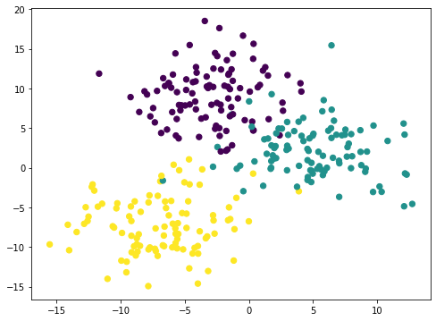

```python
from sklearn.datasets import make_blobs
import matplotlib.pyplot as plt
import numpy as np
from numpy import linalg as LA



%matplotlib inline

X, y = make_blobs(n_samples=300, centers =3, cluster_std=3.5,random_state=42)


plt.figure(figsize=(8, 6))
ax=plt.subplot(111)
ax.scatter(X[:, 0], X[:, 1], c=y, s=40, cmap='viridis')
plt.show()
```

We separate it into two parts: training data and testing data

```python
from sklearn.model_selection import train_test_split

X_train, X_test, y_train, y_test = train_test_split(X, y, test_size=0.4,
                                                    random_state=0)
```

We will use the labeled data $(X_{train}, y_{train})$ and the unlabeled data $X_{test}$ to classify the data. That is, we will treat it as a semi-supervised learning problem without using the labels of the testing data $y_{test}$.

1. Please use self training K-means method to predict the labels of the unlabeled data $X_{test}$ through the following steps:
   - For the labeled data $(X_{train}, y_{train})$, compute the centroid (mean) of each group.
   - Find the pseudo-labels of each unlabeled data according to K-means, that is, assign the label according to the closest centroid.
   - Update the centroid of each cluster by using all the labels and pseudo-labels.
   - Use the updated centroids to assign new pseudo-labels for the unlabeled data. Do not update the true labels of the labeled data.
   - Repeat the process until convergence.
2. We need the following outputs for the final result obtained in 1.
   - The centroid (mean) and variance matrix of each cluster.
   - The percentage of points in each cluster.
   - The prediction accuracy by comparing the predicted labels and the true labels $y_{test}$ of the testing data.
   - Plot all the points by using colors to distinguish the clusters and marker styles to distinguish the labeled points and unlabeled points.
3. Use semi-supervised GMM method with 3 classes to predict the labels of the unlabeled data $X_{test}$ with the following instructions:
   - Use the means, variance matrices, and the percentages obtained in 2 as the initial values.
   - Run the iterations until convergence.
   - Compute $\gamma_{j,l}$, the probability of each unlabeled point $x_j$ in each cluster $l$ and assign the labels corresponding to the largest probability.
   - Compute the prediction accuracy by comparing the predicted labels and the true labels $y_{test}$ of the testing data.
   - Plot all the points by using colors to distinguish the clusters and marker styles to distinguish the labeled points and unlabeled points.

Note: you need to upload two files in the GDrive folder: the .ipynb file containing all the codes and the .pdf file containing all the outputs and plots.

### Problem 1

- For the labeled data $(X_{train}, y_{train})$, compute the centroid (mean) of each group.

```python
# define the distance function
def dist(s,t):
    #return sum((s-t)**2)**1/2
    return np.linalg.norm(s-t, axis=1)
```

```python
class_num = 3;
```

```python
Y_new=np.zeros([len(y_train),3])
for i in range(len(y_train)):
    if y_train[i]==0:
        Y_new[i,:]=[1,0,0]
    elif y_train[i]==1:
        Y_new[i,:]=[0,1,0]
    else:
        Y_new[i,:]=[0,0,1]
```

```python
Ctrd=np.zeros([class_num,2])
for i in range(class_num):
    Ctrd[i,:]=Y_new[:,i].T@X_train/sum(Y_new[:,i])
```

```python
print(Ctrd)
```

```
[[-3.01436063  9.06597453]
 [ 5.25532093  1.99259631]
 [-6.93099031 -7.24801899]]
```

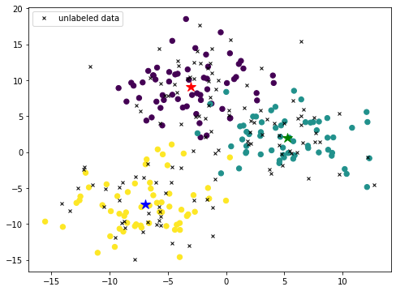

```python
plt.figure(figsize=(8, 6))

ax=plt.subplot(111)
ax.scatter(X_train[:, 0], X_train[:, 1],c=y_train, s=40, cmap='viridis')

#unlabeled data
ax.plot(X_test[:,0], X_test[:,1], color='black', marker='x', linestyle='none', linewidth=2, markersize=4, label="unlabeled data")




plt.legend(loc='upper left')


color_set = ['r', 'g', 'b', 'y', 'c', 'm']
for i in range(class_num):
    ax.plot(Ctrd[i,0], Ctrd[i,1], color=color_set[i], marker='*', linestyle='none', linewidth=2, markersize=12)
```

- Find the pseudo-labels of each unlabeled data according to K-means, that is, assign the label according to the closest centroid.

```python
Ctrd_old=np.zeros(Ctrd.shape) # store the old centroidsS
error=LA.norm(Ctrd-Ctrd_old)
print(error)
print(Ctrd)
```

```
14.947893105279393
[[-3.01436063  9.06597453]
 [ 5.25532093  1.99259631]
 [-6.93099031 -7.24801899]]
```

```python
clusters_ind=np.zeros(len(X_test))
clusters_label=np.zeros([len(X_test),class_num])
#print(clusters_label.shape)
#print(X_train.shape)
#print(X_test.shape)
X_self_learning = np.vstack([X_train,X_test])
#print(X_train,X_test)
print(X_self_learning.shape)
```

```
(300, 2)
```

```python
while error!=0:
    # assign the class for each point
    for j in range(len(X_test)):
        distances=dist(X_test[j,:], Ctrd)
        min_id=np.argmin(distances)
        clusters_ind[j]=min_id
        clusters_label[j,:]=np.eye(class_num)[min_id,:]
        #print(clusters_label[j,:])

    Y_self_learning = np.vstack([Y_new,clusters_label])
    #print(X_self_learning.shape)
    Ctrd_old=Ctrd.copy() # store the old centroids
    # update the centroids
    for i in range(class_num):
        Ctrd[i,:]=Y_self_learning[:,i].T@X_self_learning/sum(Y_self_learning[:,i])

    error=LA.norm(Ctrd_old-Ctrd)
    print("Error: ", error)
    #print(Ctrd)
    #print(Ctrd_old)
    #print(clusters_label)
```

```
Error:  0.28219204640100654
Error:  0.09942850137904832
Error:  0.09242906902218685
Error:  0.0
```

```python
def view_data(X_self_learning, Y_self_learning, title,class_num):
    plt.figure(figsize=(8, 6))

    ax=plt.subplot(111)
    plt.title(title)


    ax.scatter(X_self_learning[:, 0], X_self_learning[:, 1],c=Y_self_learning, s=40, cmap='viridis')


    color_set = ['r', 'g', 'b', 'y', 'c', 'm']
    for i in range(class_num):
        ax.plot(Ctrd[i,0], Ctrd[i,1], color=color_set[i], marker='*', linestyle='none', linewidth=2, markersize=12)
```

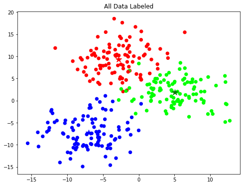

```python
title = "All Data Labeled";
view_data(X_self_learning,Y_self_learning,title, class_num);
```

### Problem 2

```python
 # compute the objective function: in-group variance
from scipy.stats import multivariate_normal

temp=0
for j in range(len(X_self_learning)):
    temp=temp+sum(Y_self_learning[j,:]*dist(X_self_learning[j,:], Ctrd))
group_variance=temp
```

```python
print(group_variance)
print(Ctrd)
```

```
1258.0761562154128
[[-2.85202468  9.3251094 ]
 [ 5.02987921  1.88233116]
 [-7.00049341 -7.23017643]]
```

```python
# Computing Percentage in each clusters
C1_id=[i for i in range(len(X_self_learning)) if np.argmax(Y_self_learning[i,:])==0]
C2_id=[i for i in range(len(X_self_learning)) if np.argmax(Y_self_learning[i,:])==1]
C3_id=[i for i in range(len(X_self_learning)) if np.argmax(Y_self_learning[i,:])==2]
#print((C1_id))

ct1 = np.array([X_self_learning[k] for k in C1_id])
ct2 = np.array([X_self_learning[k] for k in C2_id])
ct3 = np.array([X_self_learning[k] for k in C3_id])

CovCluster1=np.cov(ct1.T);
CovCluster2=np.cov(ct2.T);
cov = np.append([CovCluster1],[CovCluster2]);
CovCluster3=np.cov(ct3.T);

cov = np.array([CovCluster1,CovCluster2,CovCluster3]);
print("Covariance: \n", cov)
```

```
Covariance:
 [[[10.14276789  1.46119968]
  [ 1.46119968 11.59303575]]

 [[12.44979444 -1.50933506]
  [-1.50933506  8.21454937]]

 [[11.55302001  0.73017226]
  [ 0.73017226 12.29549289]]]
```

```python
def perc_cluster(x, y) : return len(x)/len(y)

Cluster_1_percentage = perc_cluster(C1_id, X_self_learning)
Cluster_2_percentage = perc_cluster(C2_id, X_self_learning)
Cluster_3_percentage = perc_cluster(C3_id, X_self_learning)
print("Cluster 1:", Cluster_1_percentage)
print("Cluster 2:",Cluster_2_percentage)
print("Cluster 3:",Cluster_3_percentage)
```

```
Cluster 1: 0.3333333333333333
Cluster 2: 0.3333333333333333
Cluster 3: 0.3333333333333333
```

```
-The prediction accuracy by comparing the predicted labels and the true labels $ y_{test} $  of the testing data.
```

```python
count = 0
for i in range(len(y_test)):
    #same as clusters_label is the aame as Y_self_learning[180:,:]
    if(y_test[i] ==np.argmax(clusters_label[i,:])):
        count = count +1;
percentage = count/len(y_test);
print(percentage)
```

```
0.9333333333333333
```

### Problem 3

### GMM EM Clustering Method

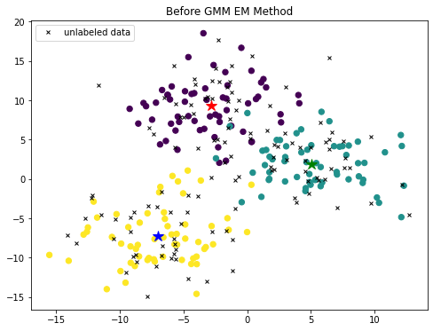

```python
#Before the GMM EM Method

plt.figure(figsize=(8, 6))

ax=plt.subplot(111)
ax.scatter(X_train[:, 0], X_train[:, 1],c=y_train, s=40, cmap='viridis')

#unlabeled data
ax.plot(X_test[:,0], X_test[:,1], color='black', marker='x', linestyle='none', linewidth=2, markersize=4, label="unlabeled data")


plt.title("Before GMM EM Method")



plt.legend(loc='upper left')


color_set = ['r', 'g', 'b', 'y', 'c', 'm']
for i in range(class_num):
    ax.plot(Ctrd[i,0], Ctrd[i,1], color=color_set[i], marker='*', linestyle='none', linewidth=2, markersize=12)
```

```python
weights = np.array([Cluster_1_percentage, Cluster_2_percentage, Cluster_3_percentage]);
print(weights);
```

```
[0.33333333 0.33333333 0.33333333]
```

```python
iter = 0;
# run GMM
error=1;
while (error>=1e-10):# exponential decay...slow at higher iteration
    print("iteration number {0} with error {1}".format(iter,error))


    likelihood_labeled = Y_new.copy();
    likelihood_unlabeled = []
  # Expectation step

    for j in range(class_num):
        likelihood_unlabeled.append(multivariate_normal.pdf(x=X_test, mean=Ctrd[j], cov=cov[j]))
    likelihood_unlabeled = np.array(likelihood_unlabeled).T

    #combine the likelihood
    likelihood= np.vstack([likelihood_labeled,likelihood_unlabeled]).T

    assert likelihood.shape == (class_num, len(X_self_learning))

    b = []
    # Maximization step
    Ctrd_old=Ctrd.copy() # store the old centroids
    for j in range(class_num):
        #print(j)
        # use the current values for the parameters to evaluate the posterior
        # probabilities of the data to have been generanted by each gaussian
        b.append((likelihood[j] * weights[j]) / (np.sum([likelihood[i] * weights[i] for i in range(class_num)], axis=0)))

        # update mean and variance
        Ctrd[j] = np.sum(b[j].reshape(len(X_self_learning),1) * X_self_learning, axis=0) / (np.sum(b[j]))
        cov[j] = np.dot((b[j].reshape(len(X_self_learning),1) * (X_self_learning - Ctrd[j])).T, (X_self_learning - Ctrd[j])) / (np.sum(b[j]))

        # update the weights
        weights[j] = np.mean(b[j])

        assert cov.shape == (class_num, X_self_learning.shape[1], X_self_learning.shape[1])
        assert Ctrd.shape == (class_num, X_self_learning.shape[1])
    error=LA.norm(Ctrd_old-Ctrd)
    iter = iter+1;
```

```
iteration number 0 with error 1
iteration number 1 with error 0.10990143153471248
iteration number 2 with error 0.02113819490158208
iteration number 3 with error 0.004906709896343709
iteration number 4 with error 0.0012219231945312195
iteration number 5 with error 0.00032259686190937723
iteration number 6 with error 9.139353362769257e-05
iteration number 7 with error 2.8423821517685634e-05
iteration number 8 with error 9.748990385897915e-06
iteration number 9 with error 3.5990403608917733e-06
iteration number 10 with error 1.385041866245647e-06
iteration number 11 with error 5.435176886250437e-07
iteration number 12 with error 2.1505573390046778e-07
iteration number 13 with error 8.537166317677542e-08
iteration number 14 with error 3.3932240901438535e-08
iteration number 15 with error 1.349267361509201e-08
iteration number 16 with error 5.365844378328795e-09
iteration number 17 with error 2.133961942690133e-09
iteration number 18 with error 8.486517302825626e-10
iteration number 19 with error 3.375001336309695e-10
iteration number 20 with error 1.342130774243215e-10
```

```python
newly_labeled = likelihood_unlabeled.copy()

#calculate accuracy for unlabeled data
count = 0
#turn likelihood to 0s and 1s
y_likelihood = np.zeros(newly_labeled.shape)

for i in range(len(y_test)):
    y_likelihood[i,np.argmax(newly_labeled[i,:])]=1;
    #same as clusters_label is the aame as Y_self_learning[180:,:]
    if(y_test[i] ==np.argmax(newly_labeled[i,:])):
        count = count +1;
percentage = count/len(y_test);
print("Percentage accuracy:", percentage)

Y_total = np.vstack([Y_new, y_likelihood])
```

```
Percentage accuracy: 0.925
```

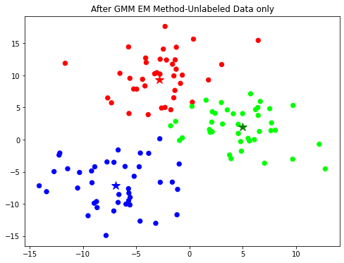

```python
title= "After GMM EM Method-Unlabeled Data only";
view_data(X_test,y_likelihood,title, class_num);
```

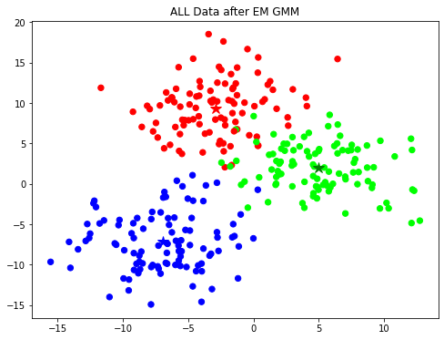

```python
title = "ALL Data after EM GMM"
view_data(X_self_learning,Y_total,title, class_num)
```